# SMART-Seq2 mRNA-Seq of 96 2cell embryos injected and nonInjected w active/dead-Btgh - DE analysis

Sara Formichetti

EMBL Rome  
sara.formichetti@embl.it

February 22, 2022

# 1 DESeq2 without removing unwanted variation

```r
dds <- DESeqDataSetFromMatrix(countData = counts_table,
                              colData = design_df,
                              design = ~ condition)
keep <- rowSums(counts(dds)) >= 10
dds <- dds[keep,]
dds <- DESeq(dds)
```

## 1.1 MA-plots

The threshold used for a dot to be colored in blue in the MA-plots is: p-value adjusted < 0.05.

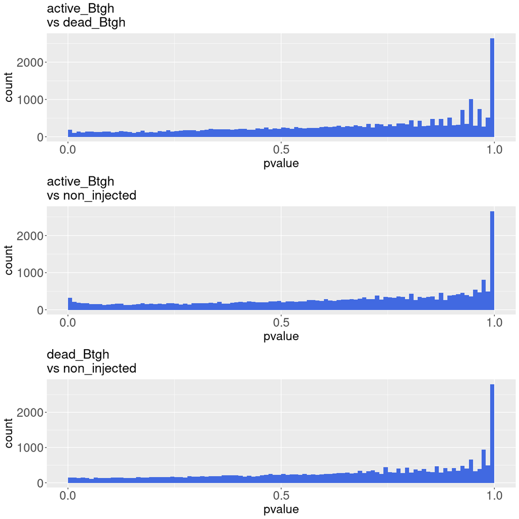

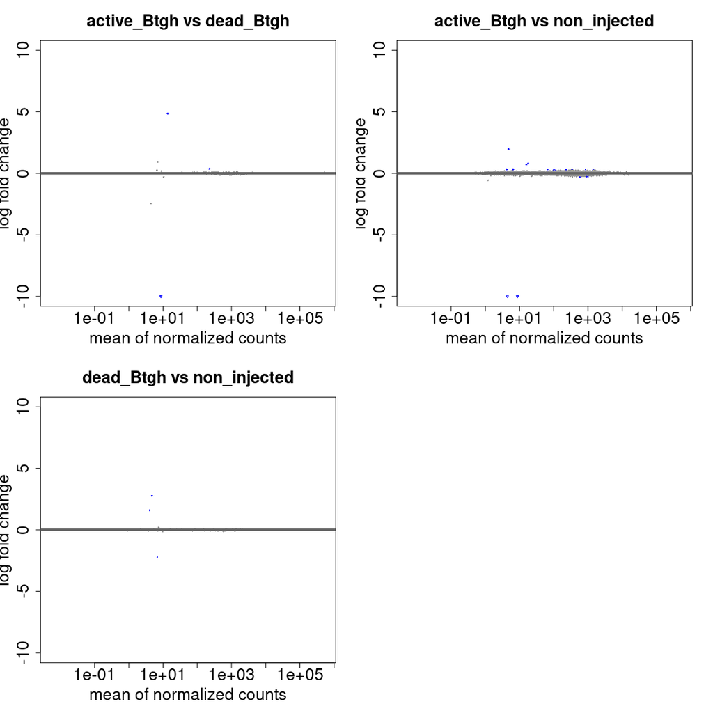

Almost no Differentially Expressed Genes.

# 2 Accounting for unwanted variation computed by RUVs in DESeq2 design formula

```r
# merging design_df with phenoData from RUVs, which contains the factors of unwanted variation
pData(ses3)$sample <- rownames(pData(ses3))
design_df <- merge(design_df, pData(ses3)[, c("sample", grep("W_", colnames(pData(ses3)), value = TRUE))], by = "sample", all = FALSE)
rownames(design_df) <- design_df$sample
counts_table <- counts_table[, rownames(design_df)]
```

```r
# creating DESeqDataset
dds_RUVs <- DESeqDataSetFromMatrix(countData = counts_table,
                                    colData = design_df,
                                    design = ~ W_1 + W_2 + W_3 + condition)
# pre-filtering low count genes
keep <- rowSums(counts(dds_RUVs)) >= 10
dds_RUVs <- dds_RUVs[keep,]
# the standard differential expression analysis steps are wrapped into a single function, DESeq
dds_RUVs <- DESeq(dds_RUVs)
# DESeq results for all comparisons
res_all_RUVs <- get_results_all_comp(dds_RUVs)
```

## 2.1 MA-plots

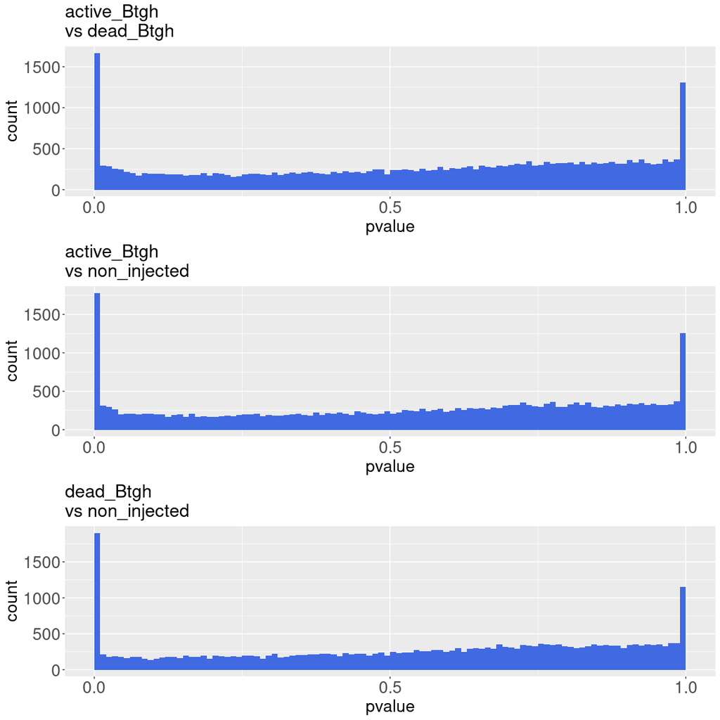

[figure not shown]

### 2.1.1 FIGURE

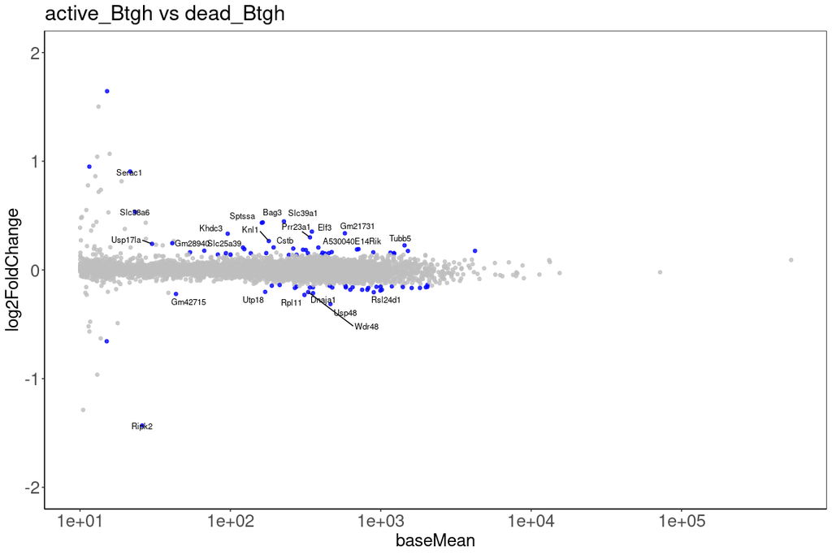

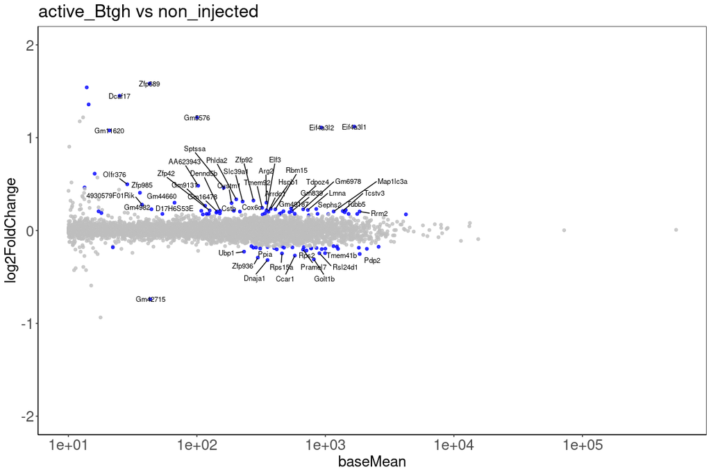

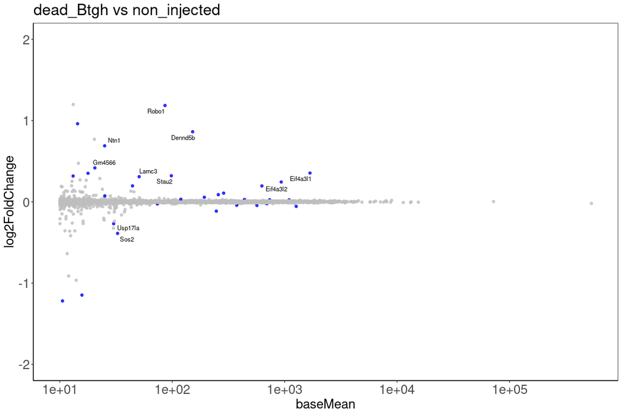

## 2.2 Gene counts for DEGs of interest

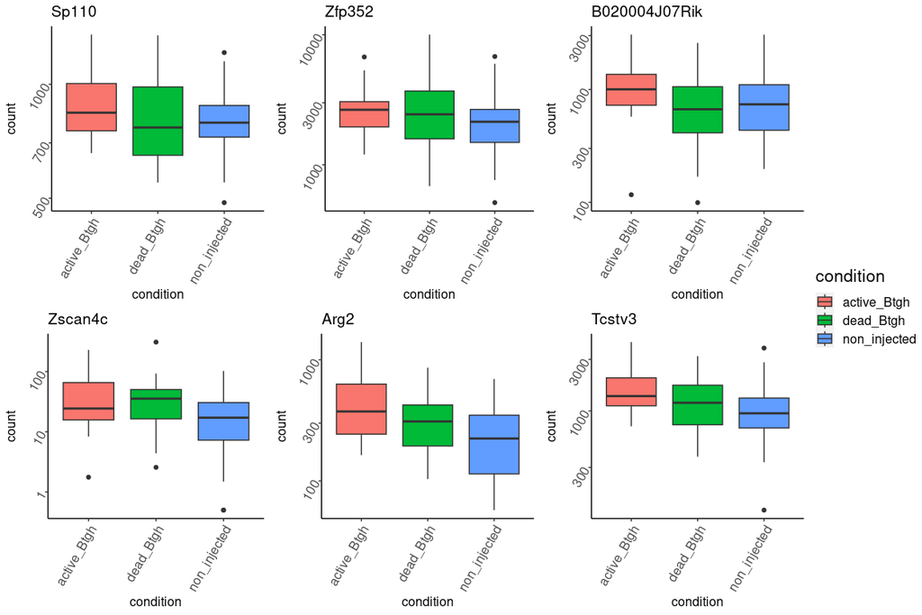

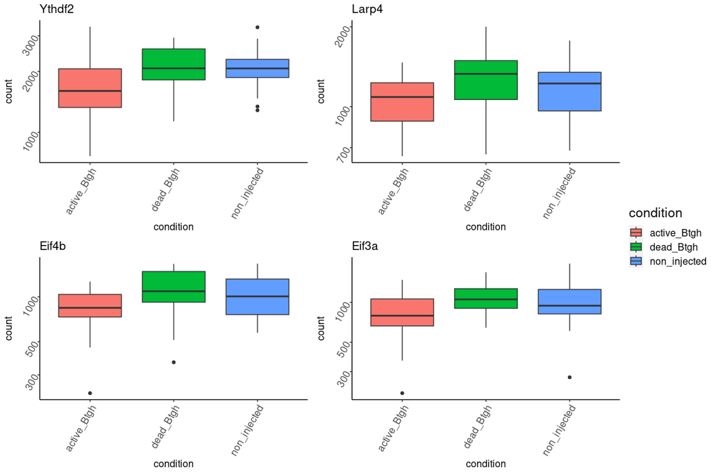

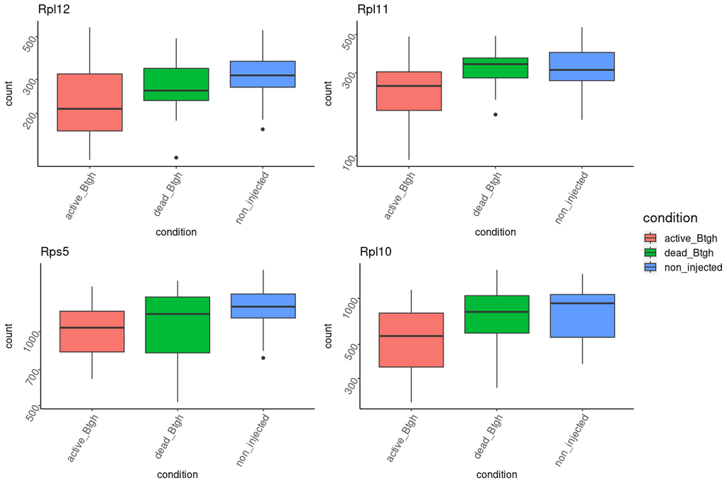

## 2.3 Ribosomal protein gene (RPG) counts

Gene names of mouse ribosomal proteins (Rpl and Rps) are from [RPG database](http://ribosome.med.miyazaki-u.ac.jp/).

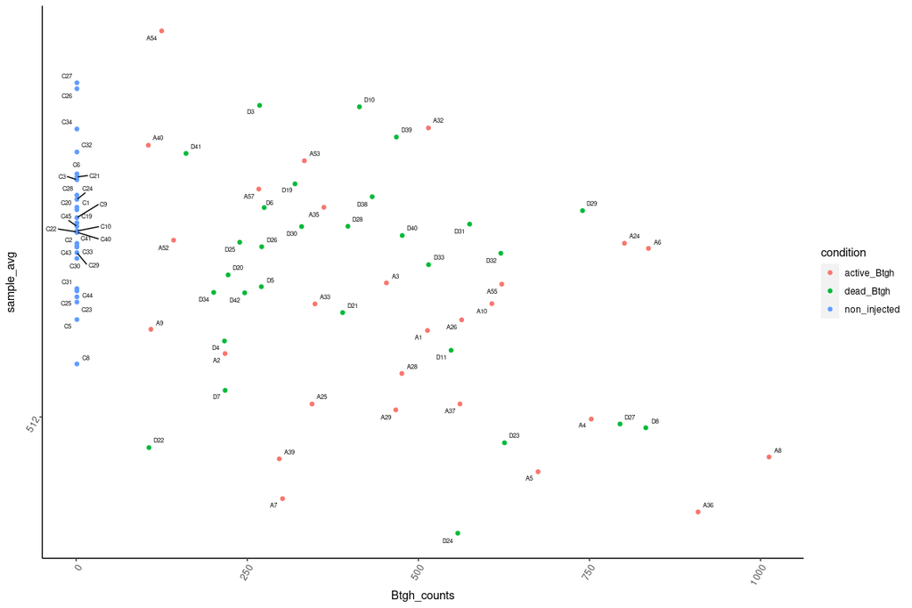

To avoid the possible effect of higher injection load on RPG counts, I remove the active samples with the highest number of Btgh molecules from next boxplot:

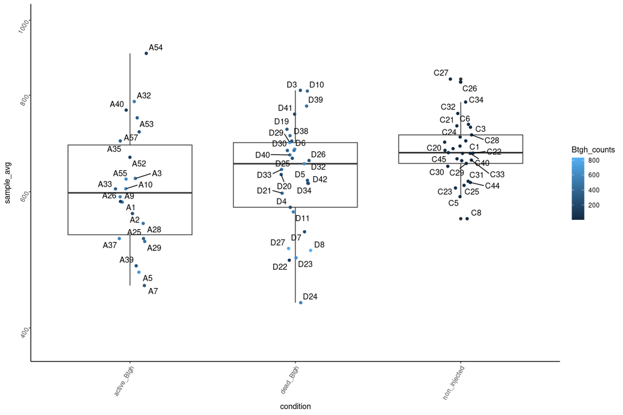

I test the difference in the distributions shown with last boxplots, using Wilcoxon test:

- pval for active vs dead is 0.3304004
- pval for active vs non-inj is 0.007175
- pval for dead vs non-inj is 0.0616803

So, even if the active vs dead comparison is not significant under threshold pval<0.05, the active vs ctrl is significant while the dead vs ctrl is not.

# 3 Test for possible slight developmental delay already starting at this stage and causing ribosomal genes downregulation

From the analysis of published dataset GSE66582 [(Wu et al., 2016)](https://www.nature.com/articles/nature18606), spanning preimplantation stages from the oocyte to the blastocyst, in OGlcNAc_early_embryo_Formichetti2023/embryo_public_data_GSE66582_GSE76505_reanalysis/src/Rmd/DE_analysis.Rmd I created a list of genes which are >2x up-regulated from the late 2-cell to the 4-cell stage.

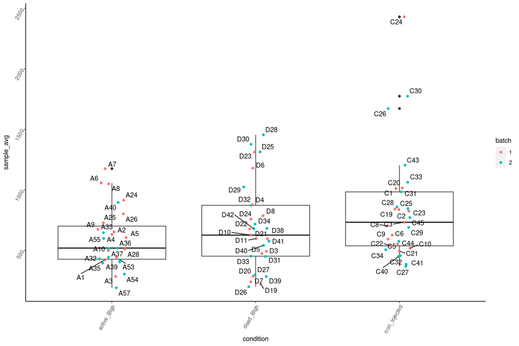

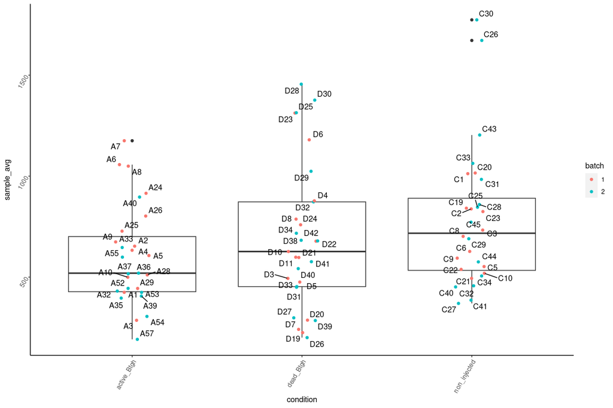

There is a slightly lower expression in Btgh-injected embryos. I test the difference in the distributions using Wilcoxon test, after removing C24:

- pval for active vs dead is 0.3877319
- pval for active vs non-inj is 0.0353359
- pval for dead vs non-inj is 0.2982525

# 4 RPG vs 2- to 4-cell upregulated genes

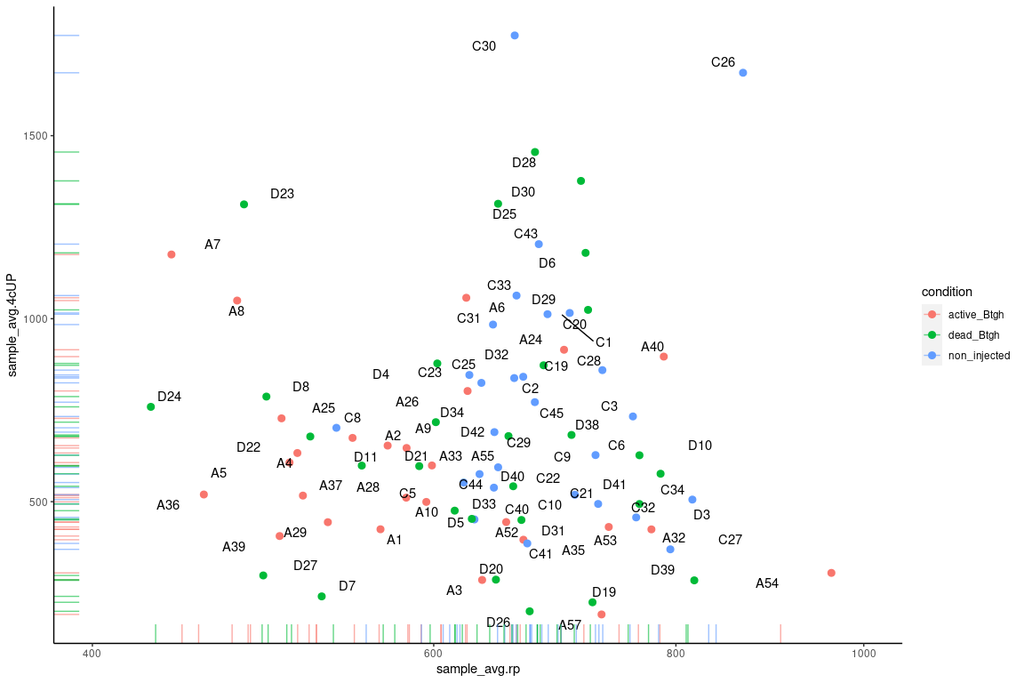